# Tugas 3 MPDW

Arfiah Kania Sektiaruni

2023-09-12

## *Packages*

```r
library(dLagM)
library(dynlm)
library(MLmetrics)
library(lmtest)
library(car)
```

## Impor Data

```r
# Yt = TS [Earth Skin Temperature (C)]
# Xt = T2M [Temperature at 2 Meters (C)]

library(rio)
datatug <- Import("https://raw.githubusercontent.com/afhkaniase/praktikum-mpdw/main/Pertemuan%203/Data%20Latihan%203.csv")

t <- datatug$Date
Yt <- datatug$TS
Xt <- datatug$T2M

data3 <- data.frame(Yt,Xt)
str(data3)
```

```
## 'data.frame':    123 obs. of  2 variables:
##  $ Yt: num  2.95 3.17 3.3 3.02 3.08 3.77 3.73 3 3.07 3.37 ...
##  $ Xt: num  4.53 7.36 5.97 2.85 2.55 4.96 3.64 0.44 1.97 2.8 ...
```

```r
data3
```

```
##        Yt    Xt
## 1    2.95  4.53
## 2    3.17  7.36
## 3    3.30  5.97
## 4    3.02  2.85
## 5    3.08  2.55
## 6    3.77  4.96
## 7    3.73  3.64
## 8    3.00  0.44
## 9    3.07  1.97
## 10   3.37  2.80
## 11   3.53  2.43
## 12   3.67  3.18
## 13   3.90  3.58
## 14   4.02  5.53
```

[output cut: 109 more lines]

## Pembagian Data

```r
#SPLIT DATA
data3_train<-data3[1:98,]
data3_test<-data3[99:123,]
```

```r
#data time series
train.ts<-ts(data3_train)
test.ts<-ts(data3_test)
data.ts<-ts(data3)
```

## Model Koyck

Model Koyck didasarkan pada asumsi bahwa semakin jauh jarak lag peubah independen dari periode sekarang maka semakin kecil pengaruh peubah lag terhadap peubah dependen.

Koyck mengusulkan suatu metode untuk menduga model dinamis distributed lag dengan mengasumsikan bahwa semua koefisien $\beta$ mempunyai tanda sama.

Model kyock merupakan jenis paling umum dari model infinite distributed lag dan juga dikenal sebagai geometric lag

$$y_t=a(1-\lambda)+\beta_0X_t+\beta_1Z_t+\lambda Y_{t-1}+V_t$$

dengan
$$V_t=u_t-\lambda
u_{t-1}$$

### Pemodelan Model Koyck

Fungsi `koyckDlm()` akan menerapkan model lag terdistribusi dengan transformasi Koyck satu prediktor. Nilai `x` dan `y` tidak perlu sebagai objek *time series* (`ts`). `intercept` dapat dibuat `TRUE` untuk memasukkan intersep ke dalam model.

```r
data3_model.koyck <- koyckDlm(x = data3_train$Xt, y = data3_train$Yt)
summary(data3_model.koyck)
```

```
##
## Call:
## "Y ~ (Intercept) + Y.1 + X.t"
##
## Residuals:
##       Min        1Q    Median        3Q       Max
## -1.306328 -0.256056  0.002453  0.208640  1.226161
##
## Coefficients:
##             Estimate Std. Error t value Pr(>|t|)
## (Intercept)  0.10931    0.13987   0.782    0.436
## Y.1          0.94879    0.03327  28.518   <2e-16 ***
## X.t          0.04974    0.03587   1.387    0.169
## ---
## Signif. codes:  0 '***' 0.001 '**' 0.01 '*' 0.05 '.' 0.1 ' ' 1
##
## Residual standard error: 0.4528 on 94 degrees of freedom
## Multiple R-Squared: 0.9953,  Adjusted R-squared: 0.9952
## Wald test: 1.002e+04 on 2 and 94 DF,  p-value: < 2.2e-16
##
## Diagnostic tests:
## NULL
##
##                             alpha       beta       phi
## Geometric coefficients:  2.134555 0.04973701 0.9487908
```

```r
AIC(data3_model.koyck)
```

```
## [1] 126.5151
```

```r
BIC(data3_model.koyck)
```

```
## [1] 136.814
```

Dari hasil tersebut, didapat bahwa peubah $y_{t-1}$ memiliki nilai $P-Value<0.05$. Hal ini menunjukkan bahwa peubah $y_{t-1}$ berpengaruh signifikan terhadap $y$. Adapun model keseluruhannya adalah sebagai berikut

$$\hat{Y_t} = 0.10931 + 0.04974X_t + 0.94879Y_{t-1}$$

### Peramalan dan Akurasi Model Koyck

Berikut adalah hasil peramalan y untuk 25 periode kedepan menggunakan model koyck

```r
fore.koyck <- forecast(model = data3_model.koyck, x=data3_test$Xt, h=25)
fore.koyck
```

```
## $forecasts
##  [1] 20.02087 20.15637 20.33019 20.53191 20.64074 20.76439 20.88618 21.04501
##  [9] 21.18526 21.27357 21.33845 21.30949 21.28748 21.38945 21.44790 21.53718
## [17] 21.65471 21.77766 21.83364 21.86636 21.93123 21.88832 21.84165 21.71231
## [25] 21.70548
##
## $call
## forecast.koyckDlm(model = data3_model.koyck, x = data3_test$Xt,
##     h = 25)
##
## attr(,"class")
## [1] "forecast.koyckDlm" "dLagM"
```

```r
#akurasi data testing
mape.koyck.test <- MAPE(fore.koyck$forecasts, data3_test$Yt)
mape.koyck.test
```

```
## [1] 0.02981854
```

```r
#akurasi data training
mape.koyck.train <- GoF(data3_model.koyck)
mape.koyck.train
```

```
##                    n       MAE          MPE       MAPE     sMAPE      MASE
## data3_model.koyck 97 0.3315851 -0.003443496 0.03339684 0.0331023 0.8322136
##                         MSE     MRAE     GMRAE
## data3_model.koyck 0.1986777 26649597 0.9770295
```

Berdasarkan akurasi di atas, terlihat bahwa nilai MAPE keduanya tidak jauh berbeda. Artinya, model regresi dengan distribusi lag ini tidak `overfitted` atau `underfitted`.

## Regression with Distributed Lag

Pemodelan model Regression with Distributed Lag dengan `R` dapat menggunakan `dLagM::dlm()` . Fungsi umum dari `dlm` adalah sebagai berikut.

```r
dlm(formula , data , x , y , q , remove )
```

Fungsi `dlm()` akan menerapkan model lag terdistribusi dengan satu atau lebih prediktor. Nilai `x` dan `y` tidak perlu sebagai objek *time series* (`ts`). $q$ adalah integer yang mewakili panjang *lag* yang terbatas.

### *Lag* Optimum Distribution Lag Model

```r
#penentuan lag optimum
finiteDLMauto(formula = Yt ~ Xt,
              data = data.frame(data3_train),
              model.type = "dlm", error.type = "AIC")
```

```
##    q - k    MASE      AIC      BIC   GMRAE   MBRAE R.Adj.Sq    Ljung-Box
## 10    10 2.25323 295.2537 327.4591 3.20525 0.52278  0.96212 2.220446e-16
```

Diperoleh lag optimum untuk peubah Xt = T2M [Temperature at 2 Meters (C)] adalah 10 hari sebelumnya. Selanjutnya dilakukan pemodelan kembali dengan $q=10$

### Pemodelan (Lag=10) Distribution Lag Model

```r
model.dlm <- dlm(x = data3_train$Xt,y = data3_train$Yt , q = 10)
summary(model.dlm)
```

```
##
## Call:
## lm(formula = model.formula, data = design)
##
## Residuals:
##      Min       1Q   Median       3Q      Max
## -2.54205 -0.77300  0.09346  0.73706  2.58880
##
## Coefficients:
##             Estimate Std. Error t value Pr(>|t|)
## (Intercept) -2.31919    0.37736  -6.146 3.39e-08 ***
## x.t          0.49601    0.10758   4.610 1.59e-05 ***
## x.1          0.10451    0.15465   0.676   0.5012
## x.2          0.10045    0.15370   0.654   0.5154
## x.3          0.02629    0.14969   0.176   0.8611
## x.4          0.06991    0.14891   0.469   0.6401
## x.5          0.11779    0.14813   0.795   0.4290
## x.6          0.03569    0.14565   0.245   0.8071
## x.7         -0.01543    0.14543  -0.106   0.9158
## x.8         -0.04417    0.14569  -0.303   0.7626
## x.9          0.02276    0.14328   0.159   0.8742
## x.10         0.16909    0.09796   1.726   0.0884 .
## ---
## Signif. codes:  0 '***' 0.001 '**' 0.01 '*' 0.05 '.' 0.1 ' ' 1
##
## Residual standard error: 1.202 on 76 degrees of freedom
## Multiple R-squared:  0.9669, Adjusted R-squared:  0.9621
## F-statistic: 201.9 on 11 and 76 DF,  p-value: < 2.2e-16
##
## AIC and BIC values for the model:
##        AIC      BIC
## 1 295.2537 327.4591
```

```r
AIC(model.dlm)
```

```
## [1] 295.2537
```

```r
BIC(model.dlm)
```

```
## [1] 327.4591
```

Dari hasil diatas, didapat bahwa $P-value$ dari intercept dan $x_{t}<0.05$. Hal ini menunjukkan bahwa intercept dan $x_{t}$ berpengaruh signifikan terhadap $y$. Adapun model keseluruhan yang terbentuk adalah sebagai berikut

$$\hat{Y_t} = - 2.31919 + 0.49601X_t + 0.10451X_{t-1} + 0.10045X_{t-2} +
0.02629X_{t-3} + 0.06991X_{t-4} + 0.11779X_{t-5} + 0.03569X_{t-6} -
0.01543X_{t-7} - 0.04417X_{t-8} + 0.02276X_{t-9} + 0.16909X_{t-10}$$

### Peramalan dan Akurasi Distribution Lag Model

Berikut merupakan hasil peramalan $y$ untuk 25 periode kedepan

```r
fore.dlm <- forecast(model = model.dlm, x=data3_test$Xt, h=25)
fore.dlm
```

```
## $forecasts
##  [1] 19.49596 19.62555 20.05032 20.94346 20.71624 20.82975 20.47847 21.03166
##  [9] 21.12570 20.81076 20.56632 19.76291 19.89415 20.94923 20.35982 20.69972
## [17] 20.92367 21.46341 21.19640 20.86884 20.99687 19.66869 19.51093 18.65288
## [25] 19.37090
##
## $call
## forecast.dlm(model = model.dlm, x = data3_test$Xt, h = 25)
##
## attr(,"class")
## [1] "forecast.dlm" "dLagM"
```

```r
#akurasi data testing
mape.dlm.test <- MAPE(fore.dlm$forecasts, data3_test$Yt)
mape.dlm.test
```

```
## [1] 0.04159384
```

```r
#akurasi data training
mape.dlm.train <- GoF(model.dlm)
mape.dlm.train
```

```
##            n       MAE         MPE      MAPE     sMAPE     MASE      MSE
## model.dlm 88 0.9269329 0.009663972 0.1142461 0.1263623 2.253232 1.248352
##               MRAE    GMRAE
## model.dlm 96906248 3.205253
```

## Model Autoregressive Distributed Lag (ARDL)

Peubah dependen dipengaruhi oleh peubah independen pada waktu sekarang, serta dipengaruhi juga oleh peubah dependen itu sendiri pada satu waktu yang lalu maka model tersebut disebut *autoregressive* (Gujarati 2004).

### Pemodelan Autoregressive Distributed Lag

Pemodelan Autoregressive dilakukan menggunakan fungsi `dLagM::ardlDlm()` . Fungsi tersebut akan menerapkan *autoregressive* berordo $(p,q)$ dengan satu prediktor. Fungsi umum dari `ardlDlm()` adalah sebagai berikut.

```r
ardlDlm(formula = NULL , data = NULL , x = NULL , y = NULL , p = 1 , q = 1 ,
         remove = NULL )
```

Dengan $p$ adalah integer yang mewakili panjang *lag* yang terbatas dan $q$ adalah integer yang merepresentasikan ordo dari proses *autoregressive*.

### Penentuan *Lag* Optimum untuk Autoregressive Distributed Lag

```r
#penentuan lag optimum
model.ardl.opt <- ardlBoundOrders(data = data.frame(data3), ic = "AIC",
                                  formula = Yt ~ Xt )
min_p=c()
for(i in 1:15){
  min_p[i]=min(model.ardl.opt$Stat.table[[i]])
}
q_opt=which(min_p==min(min_p, na.rm = TRUE))
p_opt=which(model.ardl.opt$Stat.table[[q_opt]] ==
              min(model.ardl.opt$Stat.table[[q_opt]], na.rm = TRUE))
data.frame("q_optimum" = q_opt, "p_optimum" = p_opt,
           "AIC"=model.ardl.opt$min.Stat)
```

```
##   q_optimum p_optimum      AIC
## 1         2         1 30.82842
```

Dari tabel di atas, dapat terlihat bahwa nilai AIC terendah didapat ketika $p=1$ dan $q=2$, yaitu sebesar `30.82842`. Artinya, model autoregressive optimum didapat ketika $p=1$ dan $q=2$. Selanjutnya nilai ini akan dimasukkan ke dalam proses pembentukan model ardl.

```r
model.ardl <- ardlDlm(x = data3_train$Xt, y = data3_train$Yt, p = 1 , q = 2)
summary(model.ardl)
```

```
##
## Time series regression with "ts" data:
## Start = 3, End = 98
##
## Call:
## dynlm(formula = as.formula(model.text), data = data, start = 1)
##
## Residuals:
##      Min       1Q   Median       3Q      Max
## -0.66789 -0.20311  0.03346  0.17545  0.94769
##
## Coefficients:
##             Estimate Std. Error t value Pr(>|t|)
## (Intercept)  0.03384    0.08123   0.417    0.678
## X.t          0.21466    0.02292   9.367 5.37e-15 ***
## X.1         -0.18353    0.02535  -7.239 1.40e-10 ***
## Y.1          1.42815    0.07840  18.215  < 2e-16 ***
## Y.2         -0.46053    0.06785  -6.787 1.14e-09 ***
## ---
## Signif. codes:  0 '***' 0.001 '**' 0.01 '*' 0.05 '.' 0.1 ' ' 1
##
## Residual standard error: 0.295 on 91 degrees of freedom
## Multiple R-squared:  0.998,  Adjusted R-squared:  0.998
## F-statistic: 1.16e+04 on 4 and 91 DF,  p-value: < 2.2e-16
```

```r
AIC(model.ardl)
```

```
## [1] 44.89524
```

```r
BIC(model.ardl)
```

```
## [1] 60.28133
```

$$\hat{Y} = 0.03384 + 0.21466X_t - 0.18353X_{t-1} + 1.42815Y_{t-1} -
0.46053Y_{t-2}$$

### Peramalan dan Akurasi Model Autoregressive Distributed Lag

```r
fore.ardl <- forecast(model = model.ardl, x=data3_test$Xt, h=25)
fore.ardl
```

```
## $forecasts
##  [1] 20.10104 20.37227 20.72478 21.09513 20.96957 21.01235 21.07536 21.31587
##  [9] 21.42559 21.31687 21.19468 20.74931 20.52716 20.92502 20.97693 21.15512
## [17] 21.40257 21.60215 21.46913 21.32313 21.39710 20.99440 20.74486 20.22891
## [25] 20.42095
##
## $call
## forecast.ardlDlm(model = model.ardl, x = data3_test$Xt, h = 25)
##
## attr(,"class")
## [1] "forecast.ardlDlm" "dLagM"
```

Data di atas merupakan hasil peramalan untuk 25 periode ke depan menggunakan Model Autoregressive dengan $p=1$ dan $q=2$.

```r
#akurasi data testing
mape.ardl.test <- MAPE(fore.ardl$forecasts, data3_test$Yt)
mape.ardl.test
```

```
## [1] 0.0171622
```

```r
#akurasi data training
mape.ardl.train <- GoF(model.ardl)
mape.ardl.train
```

```
##             n       MAE          MPE       MAPE      sMAPE      MASE        MSE
## model.ardl 96 0.2300173 -0.000136184 0.02438607 0.02433235 0.5732331 0.08247844
##                MRAE     GMRAE
## model.ardl 57837119 0.7241981
```

## Perbandingan Model

```r
akurasi <- matrix(c(mape.koyck.test, mape.dlm.test, mape.ardl.test))
row.names(akurasi)<- c("Koyck","DLM","Autoregressive")
colnames(akurasi) <- c("MAPE")
akurasi
```

```
##                      MAPE
## Koyck          0.02981854
## DLM            0.04159384
## Autoregressive 0.01716220
```

### Plot

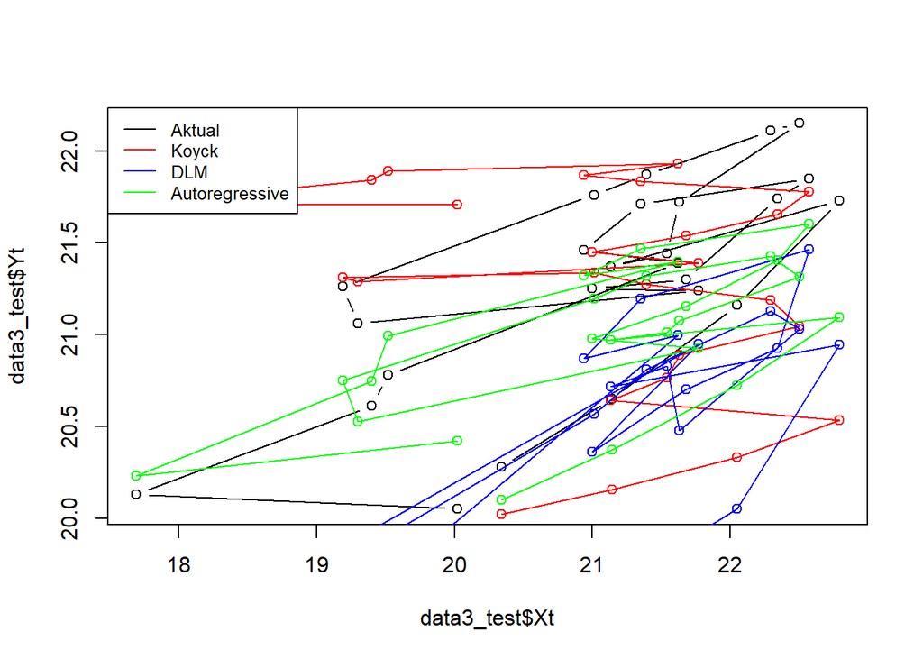

```r
par(mfrow=c(1,1))
plot(data3_test$Xt, data3_test$Yt, type="b", col="black")
points(data3_test$Xt, fore.koyck$forecasts,col="red")
lines(data3_test$Xt, fore.koyck$forecasts,col="red")
points(data3_test$Xt, fore.dlm$forecasts,col="blue")
lines(data3_test$Xt, fore.dlm$forecasts,col="blue")
points(data3_test$Xt, fore.ardl$forecasts,col="green")
lines(data3_test$Xt, fore.ardl$forecasts,col="green")
legend("topleft",c("Aktual", "Koyck","DLM", "Autoregressive"), lty=1, col=c("black","red","blue","green"), cex=0.8)
```

Berdasarkan plot tersebut, terlihat bahwa model Autoregressive Distributed Lag merupakan metode yang paling sesuai untuk melakukan peramalan pada data suhu di US karena memiliki pola data aktual. Sehingga dapat disimpulkan model terbaik dalam hal ini adalah model regresi Autoregressive Distributed Lag.